# Final Assignment

Hans-Christian Lindner

24 Januar 2018

# Manifestation of the climate change in Texas over the past 70 years

## Introduction and research questions:

We know about the climate change and it’s consequences since many years and a lot of research has been done in this field. To examine these consequences on a real world example on my own I chose Texas as a very large but also very interseting state of the USA with many different climatic conditions. To have a deeper look on the consequences I will analyze the wind speed, the maximum temperature, the precipitation and the evaporation measured on different weather stations across the state over the last 70 years. To handle that large amount of data I will use only the January and the August of every ten years from 1945 to 2015. Furthermore I will analyze continuous timeseries data from 4 different stations that are located in different parts of the state with data from 1950 until today. The research question then is: How has the climate changed in the past 70 years in Texas regarding the different climate parameters precipitation, temperature, wind and evaporation? Side questions to that would be: Are there differences between the climate change at the coast and in the interior and what is the forecast for the next years? Will it be stronger or could the climate change also become weaker?

## Hypotheses:

I expect that the maximum temperature, the evaporation and the average wind speed will get higher over time. The precipitation will get lower due to the loss of water (maybe this will be different at the coast). So I expect to see a remarkable change in the climate. The changes in the interior should be bigger than at the coast because of a stronger warming of the soil. The forecast will be even worse and the changes in the climatic parameters will be stronger in a shorter time.

## Data and some results:

## Timeseries data of four stations in Texas:

There are as an example the timeseries plots for maximum temperature, evaporation and precipitation for the weather station “Mccook” in the south west of Texas. In the next plot are the locations of the 4 different observed stations marked.

[output not shown]

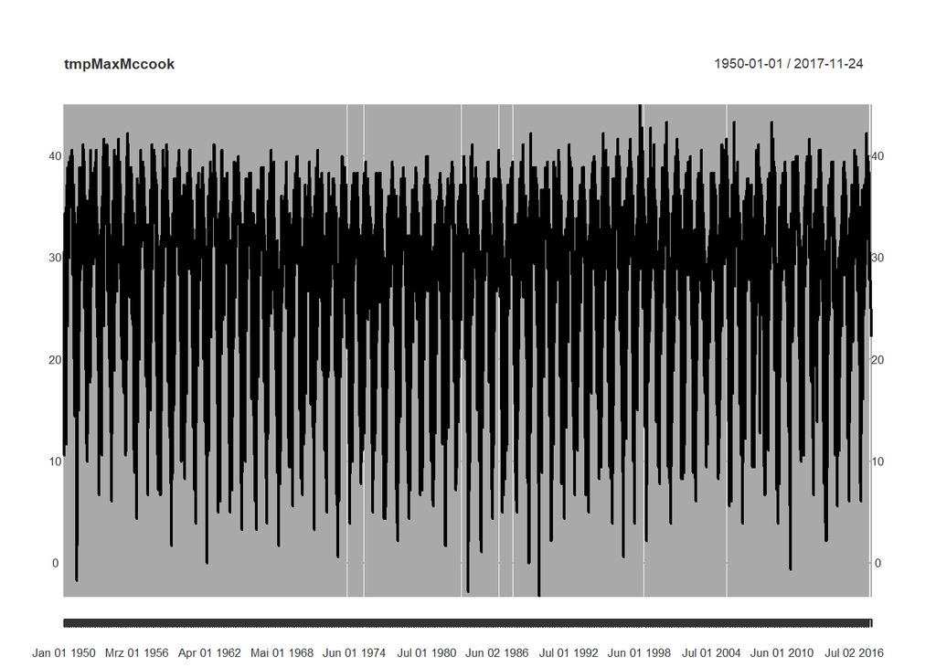

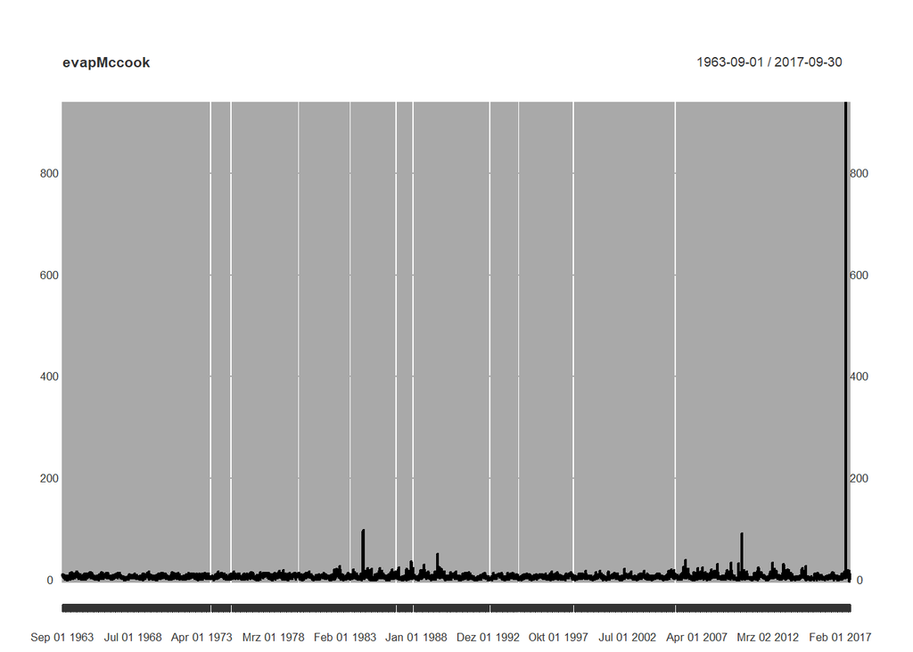

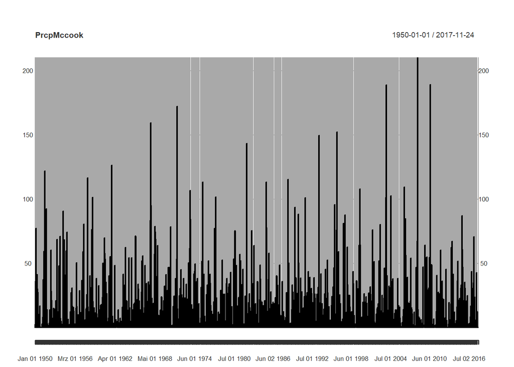

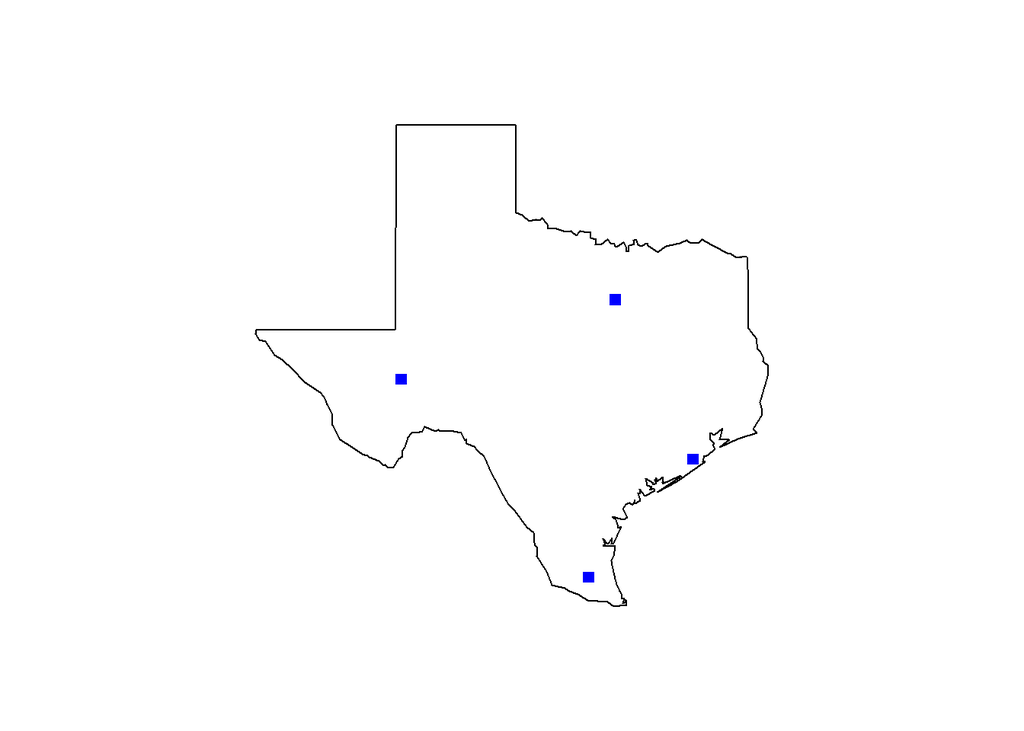

## Data from all stations in Texas from different years for every January and August:

First plot is the head of the temperature dataset of all station for the January of 2015, followed by the same datasets for evaporation, wind and precipitation.

After that there is the plot with all stations for the different categories for the January of 2015 (with doubles).

The other plot is the same with all stations from January of 1945. In 1945 there was only one station which collected evaporation values and wind values are only collected since 1980

```
## # A tibble: 6 x 7
##       STATION                  NAME LATITUDE LONGITUDE ELEVATION
##         <chr>                 <chr>    <dbl>     <dbl>     <dbl>
## 1 USW00003951 LONGVIEW 11 SE, TX US  32.3466  -94.6533     124.1
## 2 USW00003951 LONGVIEW 11 SE, TX US  32.3466  -94.6533     124.1
## 3 USW00003951 LONGVIEW 11 SE, TX US  32.3466  -94.6533     124.1
## 4 USW00003951 LONGVIEW 11 SE, TX US  32.3466  -94.6533     124.1
## 5 USW00003951 LONGVIEW 11 SE, TX US  32.3466  -94.6533     124.1
## 6 USW00003951 LONGVIEW 11 SE, TX US  32.3466  -94.6533     124.1
## # ... with 2 more variables: DATE <dttm>, TMAX <dbl>
```

```
## # A tibble: 6 x 7
##       STATION                          NAME LATITUDE LONGITUDE ELEVATION
##         <chr>                         <chr>    <dbl>     <dbl>     <dbl>
## 1 USC00411880 COLETO CREEK RESERVOIR, TX US 28.71556 -97.17417        36
## 2 USC00411880 COLETO CREEK RESERVOIR, TX US 28.71556 -97.17417        36
## 3 USC00411880 COLETO CREEK RESERVOIR, TX US 28.71556 -97.17417        36
## 4 USC00411880 COLETO CREEK RESERVOIR, TX US 28.71556 -97.17417        36
## 5 USC00411880 COLETO CREEK RESERVOIR, TX US 28.71556 -97.17417        36
## 6 USC00411880 COLETO CREEK RESERVOIR, TX US 28.71556 -97.17417        36
## # ... with 2 more variables: DATE <dttm>, EVAP <dbl>
```

```
## # A tibble: 6 x 7
##       STATION                          NAME LATITUDE LONGITUDE ELEVATION
##         <chr>                         <chr>    <dbl>     <dbl>     <dbl>
## 1 USW00003971 DALLAS REDBIRD AIRPORT, TX US 32.68083 -96.86806     200.6
## 2 USW00003971 DALLAS REDBIRD AIRPORT, TX US 32.68083 -96.86806     200.6
## 3 USW00003971 DALLAS REDBIRD AIRPORT, TX US 32.68083 -96.86806     200.6
## 4 USW00003971 DALLAS REDBIRD AIRPORT, TX US 32.68083 -96.86806     200.6
## 5 USW00003971 DALLAS REDBIRD AIRPORT, TX US 32.68083 -96.86806     200.6
## 6 USW00003971 DALLAS REDBIRD AIRPORT, TX US 32.68083 -96.86806     200.6
## # ... with 2 more variables: DATE <dttm>, AWND <dbl>
```

```
## # A tibble: 6 x 7
##       STATION                  NAME LATITUDE LONGITUDE ELEVATION
##         <chr>                 <chr>    <dbl>     <dbl>     <dbl>
## 1 USW00003951 LONGVIEW 11 SE, TX US  32.3466  -94.6533     124.1
## 2 USW00003951 LONGVIEW 11 SE, TX US  32.3466  -94.6533     124.1
## 3 USW00003951 LONGVIEW 11 SE, TX US  32.3466  -94.6533     124.1
## 4 USW00003951 LONGVIEW 11 SE, TX US  32.3466  -94.6533     124.1
## 5 USW00003951 LONGVIEW 11 SE, TX US  32.3466  -94.6533     124.1
## 6 USW00003951 LONGVIEW 11 SE, TX US  32.3466  -94.6533     124.1
## # ... with 2 more variables: DATE <dttm>, PRCP <dbl>
```

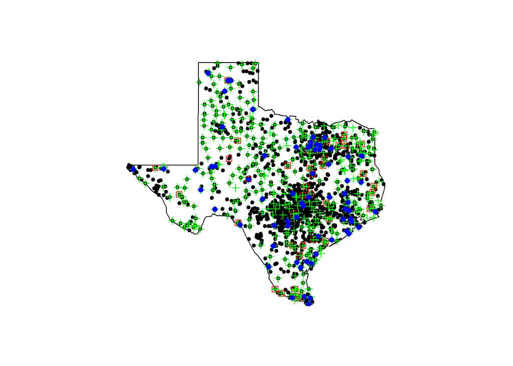

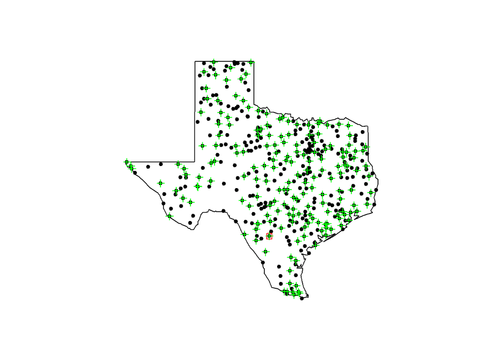

## What am I planning to do with the data/which methods I use:

I will do a timeseries analysis with the four timeseries of the stations and compare the results to see if there are differences between the coast and the interior. To see what happens in the next years I will compute forecasts for the different climate parameters. For the datasets of all stations in Texas of the different years I will compute variograms first and then do kriging to get an overview over the data and then compare the results. I could also take a look on the spatial correlation of the different climate parameters.